# Bibliometric impact assessment with the CITAN package

MTE: Tecnologías de Gestión de Datos

CITAN 2019.3.1 : 2019-10-02

The practical usability of the CITation ANalysis package for R statistical computing environment, is shown. The main aim of the software is to support bibliometricians with a tool for preprocessing and cleaning bibliographic data retrieved from SciVerse Scopus and for calculating the most popular indices of scientific impact.

https://cran.r-project.org/web/packages/CITAN/index.html

https://cran.r-project.org/web/packages/CITAN/CITAN.pdf

https://github.com/gagolews/CITAN

https://www.gagolewski.com/publications/2011citan.pdf

```r
library(CITAN)
```

Sin embargo, la función `Scopus_ReadCSV()` produce un error en Windows. Para corregirlo:

```r
# Session > Set Working Directory > To Source...
source("Scopus_ReadCSV2.R")
```

## Creación de la base de datos

Se generará el archivo:

```r
dbfilename <- "UDC2015.db"
```

### Primera ejecución: Creación del modelo de DB

Creación del archivo de BD vacío:

```r
conn <- lbsConnect(dbfilename)
```

Creación del esquema con [`lbsCreate()`](https://www.rdocumentation.org/packages/CITAN/versions/2015.12-2/topics/lbsCreate):

```r
lbsCreate(conn)
```

Importar información de Scopus (descargada previamente…) con la función [`Scopus_ImportSources()`](https://www.rdocumentation.org/packages/CITAN/versions/2015.12-2/topics/Scopus_ImportSources) ([código](https://github.com/gagolews/CITAN/blob/master/R/scopus.importsources.R)):

```r
Scopus_ImportSources(conn) # Cuidado con el tiempo de CPU...
```

```
## Importing Scopus ASJC codes... Done, 334 records added.
## Importing Scopus source list...

## Warning in doTryCatch(return(expr), name, parentenv, handler): No ASJC @
## row=510.

## Warnings... __TRUNCATED__

## Done, 30787 of 30794 records added; 55297 ASJC codes processed.
## Note: 7 records omitted @ rows=13847,15526,16606,17371,19418,24419,29365.

## [1] TRUE
```

### Incorporar nuevos datos

Con la función `Scopus_ReadCSV()` se produce un error en Windows:

```r
data <-  Scopus_ReadCSV("udc_2015.csv")
```

```
## Error in Scopus_ReadCSV("udc_2015.csv") : Column not found: `Source'.
```

Empleando la versión modificada:

```r
data <-  Scopus_ReadCSV2("udc_2015.csv")
```

Añadir los documentos a la base de datos:

```r
lbsImportDocuments(conn, data)
```

```
## Importing documents and their authors... Importing 1324 authors... 1324 new authors added.

## Warning in .lbsImportDocuments_Add_Get_idSource(conn, record$SourceTitle, :
## no source with sourceTitle=''Quaternary Science Reviews'' found for record
## 10. Setting IdSource=NA.

## Warnings... __TRUNCATED__

## Done, 363 of 363 new records added to Default survey/udc_2015.csv.

## [1] TRUE
```

Se podría añadir una descripción para trabajar con distintos grupos de documentos:

```r
lbsImportDocuments(conn, data, "udc_2015")
```

## Extraer información de la BD

En siguientes ejecuciones bastará con conectar con la BD

```r
conn <- lbsConnect(dbfilename)
```

### Estadísticos descriptivos

```r
lbsDescriptiveStats(conn)
```

```
## Number of sources in your LBS:           30787
## Number of documents in your LBS:         363
## Number of author records in your LBS:    1324
## Number of author groups in your LBS:     1
## Number of ungrouped authors in your LBS: 1324
##
## You have chosen the following data restrictions:
##  Survey:         <ALL>.
##  Document types: <ALL>.
##
## Surveys:
##   surveyDescription DocumentCount
## 1    Default survey           363
##   * Note that a document may belong to many surveys/files.
```

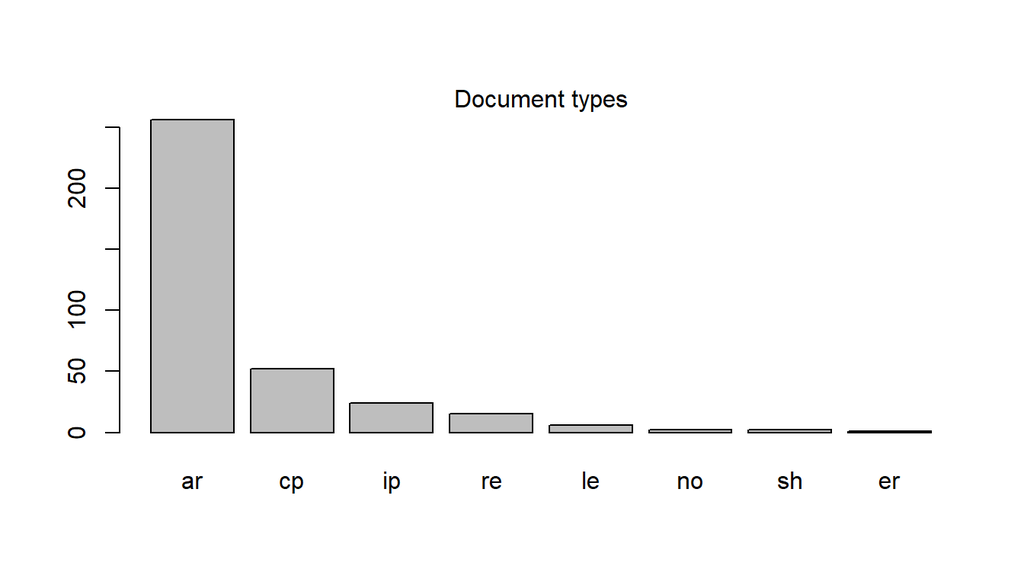

```
## Document types:
##
##  ar  cp  ip  re  le  no  sh  er
## 256  52  24  15   6   2   2   1
```

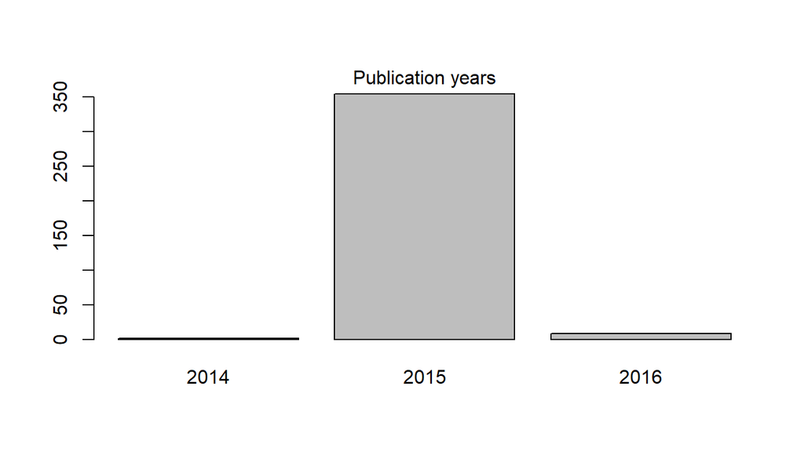

```
## Publication years:
##
## 2014 2015 2016
##    1  354    8
```

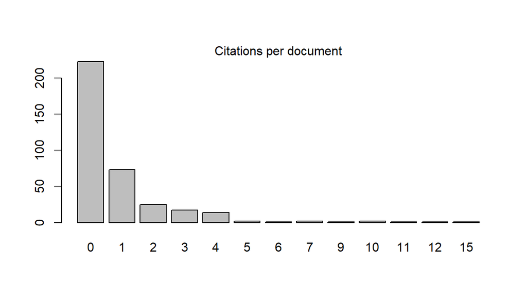

```
## Citations per document:
##
##   0   1   2   3   4   5   6   7   9  10  11  12  15
## 223  73  25  17  14   2   1   2   1   2   1   1   1
```

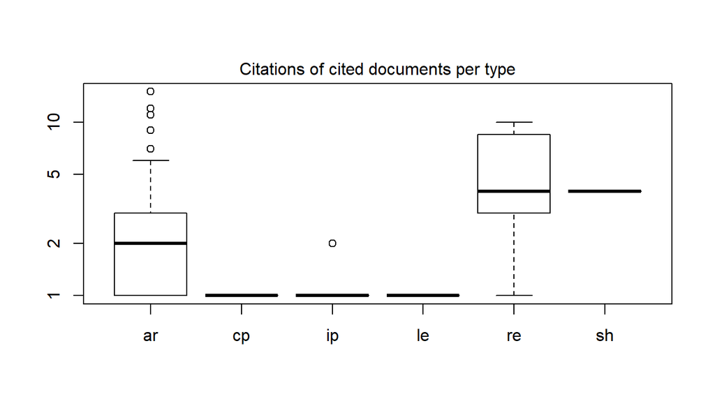

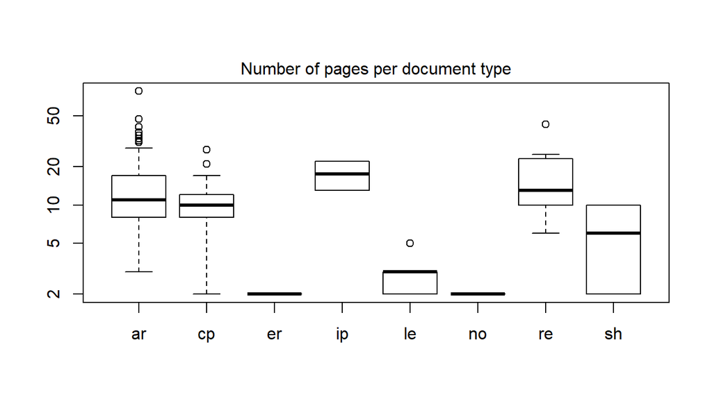

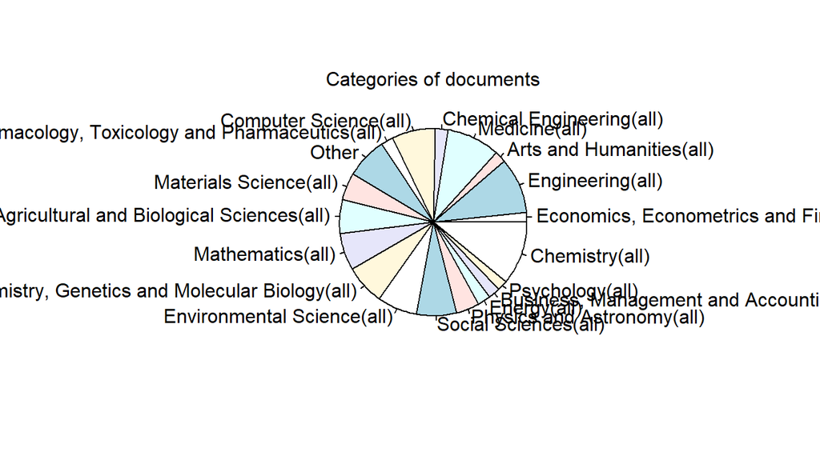

```
## Categories of documents:
##          Economics, Econometrics and Finance(all)
##                                                 8
##                                  Engineering(all)
##                                                45
##                          Arts and Humanities(all)
##                                                 9
##                                     Medicine(all)
##                                                43
##                         Chemical Engineering(all)
##                                                10
##                             Computer Science(all)
##                                                35
##   Pharmacology, Toxicology and Pharmaceutics(all)
##                                                10
##                                             Other
##                                                33
##                            Materials Science(all)
##                                                22
##         Agricultural and Biological Sciences(all)
##                                                27
##                                  Mathematics(all)
##                                                30
## Biochemistry, Genetics and Molecular Biology(all)
##                                                32
##                        Environmental Science(all)
##                                                32
##                              Social Sciences(all)
##                                                32
##                        Physics and Astronomy(all)
##                                                19
##                                       Energy(all)
##                                                10
##          Business, Management and Accounting(all)
##                                                10
##                                   Psychology(all)
##                                                 8
##                                    Chemistry(all)
##                                                51
```

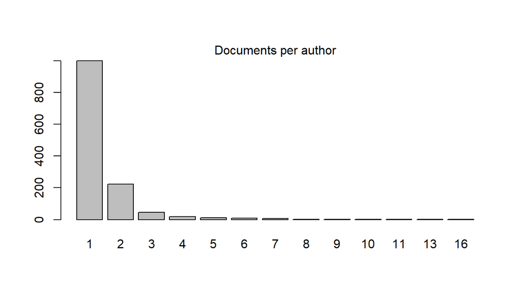

```
## Documents per author:
##
##    1    2    3    4    5    6    7    8    9   10   11   13   16
## 1000  224   46   18   12    8    6    1    1    2    2    1    1
```

### Otra información

Se puede obtener información acerca de los documentos producidos y las citas recibidas correspondientes a cada autor:

```r
citseq <- lbsGetCitations(conn)
```

```
## Data set restrictions:
##  Survey:         <ALL>.
##  Document types: <ALL>.
##
## Creating citation sequences... OK, 1322 of 1322 records read.
```

```r
# citseq <- lbsGetCitations(conn, surveyDescription="udc_2015")
```

Número de autores

```r
length(citseq)
```

```
## [1] 1322
```

```r
head(names(citseq))
```

```
## [1] "LÓPEZ-GARCÍA X."   "MARWAH S."         "OTERO T.P."
## [4] "IGLESIAS M.P."     "GONZÁLEZ-RIVAS D." "BARROS CASTRO J."
```

```r
citseq[[4]]
```

```
## 229  11
##   1   0
## attr(,"IdAuthor")
## [1] 4
```

Se pueden seleccionar autores:

```r
id <- lbsSearchAuthors(conn, c("Cao R.", "Naya S.", "Naya-Fernandez S."))
id
```

```
## [1]   46 1193
```

Obtener las citas de los trabajos de los autores seleccionados:

```r
citseq2 <- lbsGetCitations(conn, idAuthors=id)
```

```
## Data set restrictions:
##  Survey:         <ALL>.
##  Document types: <ALL>.
##
## Creating citation sequences... OK, 2 of 2 records read.
```

```r
length(citseq2)
```

```
## [1] 2
```

Obtener los documentos relativos a los autores seleccionados:

```r
id_re  <-  lbsSearchDocuments(conn, idAuthors=id)
```

Obtener información acerca de los documentos:

```r
info_re <- lbsGetInfoDocuments(conn, id_re)
info_re
```

```
## [[1]]
## IdDocument:    16
## AlternativeId: 2-s2.0-84947552209
## Title:         Lifetime estimation applying a kinetic model based on the generalized logistic function to biopolymers
## BibEntry:      Journal of Thermal Analysis and Calorimetry,2015,122,3,,1203,1212
## Year:          2015
## Type:          Article
## Citations:     0
## Authors:       NAYA S./46/NA, ÁLVAREZ A./518/NA, LÓPEZ-BECEIRO J./565/NA, GARCÍA-PARDO S./624/NA, TARRÍO-SAAVEDRA J./631/NA, QUINTANA-PITA S./709/NA, GARCÍA-SABÁN F.J./978/NA
##
## [[2]]
## IdDocument:    98
## AlternativeId: 2-s2.0-84928890357
## Title:         Bootstrap testing for cross-correlation under low firing activity
## BibEntry:      Journal of Computational Neuroscience,2015,38,3,,577,587
## Year:          2015
## Type:          Article
## Citations:     1
## Authors:       ESPINOSA N./779/NA, MARIÑO J./832/NA, CUDEIRO J./1096/NA, CAO R./1193/NA, GONZÁLEZ-MONTORO A.M./1294/NA
##
## [[3]]
## IdDocument:    127
## AlternativeId: 2-s2.0-84939982743
## Title:         Classification of wood using differential thermogravimetric analysis
## BibEntry:      Journal of Thermal Analysis and Calorimetry,2015,120,1,,541,551
## Year:          2015
## Type:          Article
## Citations:     0
## Authors:       NAYA S./46/NA, LÓPEZ-BECEIRO J./565/NA, TARRÍO-SAAVEDRA J./631/NA, FRANCISCO-FERNÁNDEZ M./766/NA, ARTIAGA R./1112/NA
```

Obtener las citas de cada documento:

```r
cit_re  <-  sapply(info_re,  function(x)  x$Citations)
cit_re
```

```
## [1] 0 1 0
```

## Cerrar conexión

```r
lbsDisconnect(conn)
```